```
                               INDIAN STARTUP FINDING ANALYSIS!!!
```

# KIND OF QUESTION CAN WE ASK FROM PARTICULAR DATASET..??

1. How much funds does startups generally get in india?(maximum funding,minimum funding ).
2. Which indutries are favored by investors for funding?(OR)Which type of companies got more easilt funding.?
3. Do cities play a major role in funding ? (OR) Which city has maximum startups ?
4. Who is the important investors in the Indian Ecosystem?
5. What are different types of funding for startups ?

# Wrangling/Munging the Data..!!

1. Gathering Data

```python
import pandas as pd
from matplotlib import pyplot as plt
%matplotlib inline
df=pd.read_csv("F:\startup_funding1.csv")
df
```

|  | SNo | Date | StartupName | IndustryVertical | SubVertical | CityLocation | InvestorsName | InvestmentType | AmountInUSD | Remarks |
| --- | --- | --- | --- | --- | --- | --- | --- | --- | --- | --- |
| 0 | 0 | 01-08-2017 | TouchKin | Technology | Predictive Care Platform | Bangalore | Kae Capital | Private Equity | 13,00,000 | NaN |
| 1 | 1 | 02-08-2017 | Ethinos | Technology | Digital Marketing Agency | Mumbai | Triton Investment Advisors | Private Equity | NaN | NaN |
| 2 | 2 | 02-08-2017 | Leverage Edu | Consumer Internet | Online platform for Higher Education Services | New Delhi | Kashyap Deorah, Anand Sankeshwar, Deepak Jain,... | Seed Funding | NaN | NaN |
| 3 | 3 | 02-08-2017 | Zepo | Consumer Internet | DIY Ecommerce platform | Mumbai | Kunal Shah, LetsVenture, Anupam Mittal, Hetal ... | Seed Funding | 5,00,000 | NaN |
| 4 | 4 | 02-08-2017 | Click2Clinic | Consumer Internet | healthcare service aggregator | Hyderabad | Narottam Thudi, Shireesh Palle | Seed Funding | 8,50,000 | NaN |
| 5 | 5 | 01-07-2017 | Billion Loans | Consumer Internet | Peer to Peer Lending platform | Bangalore | Reliance Corporate Advisory Services Ltd | Seed Funding | 10,00,000 | NaN |
| 6 | 6 | 03-07-2017 | Ecolibriumenergy | Technology | Energy management solutions provider | Ahmedabad | Infuse Ventures, JLL | Private Equity | 26,00,000 | NaN |
| 7 | 7 | 04-07-2017 | Droom | eCommerce | Online marketplace for automobiles | Gurgaon | Asset Management (Asia) Ltd, Digital Garage Inc | Private Equity | 2,00,00,000 | NaN |
| 8 | 8 | 05-07-2017 | Jumbotail | eCommerce | online marketplace for food and grocery | Bangalore | Kalaari Capital, Nexus India Capital Advisors | Private Equity | 85,00,000 | NaN |
| 9 | 9 | 05-07-2017 | Moglix | eCommerce | B2B marketplace for Industrial products | Noida | International Finance Corporation, Rocketship,... | Private Equity | 1,20,00,000 | NaN |
| 10 | 10 | 05-07-2017 | Timesaverz | Consumer Internet | Hyperlocal home services provider | Mumbai | BCCL | Private Equity | 10,00,000 | NaN |
| 11 | 11 | 06-07-2017 | Minjar | Technology | Cloud Solutions provider | Bangalore | Blume Ventures, Contrarian Capital India Partn... | Seed Funding | NaN | NaN |
| 12 | 12 | 06-07-2017 | MyCity4kids | Consumer Internet | parenting blog and kids’ events discovery plat... | Gurgaon | NaN | Seed Funding | NaN | NaN |
| 13 | 13 | 07-07-2017 | Clip App | Consumer Internet | Digital Media Video platform | Bangalore | India Quotient, Shunwei Capital | Seed Funding | 10,00,000 | NaN |
| 14 | 14 | 07-07-2017 | Upwardly.in | Consumer Internet | MF investment platform | Bangalore | Sreeram Iyer, Suvo Sarkar, Anita Gupta, Likemi... | Seed Funding | NaN | NaN |
| 15 | 15 | 10-07-2017 | Autorox.co | Technology | Workshop Management Software Platform | Hyderabad | Mitsui & Co. | Private Equity | 30,00,000 | NaN |
| 16 | 16 | 11-07-2017 | Fabogo | Consumer Internet | Salon & Spa Aggregation & Discovery platform | Pune | Dunamis Ventures Pte Ltd | Private Equity | 22,50,000 | NaN |
| 17 | 17 | 11-07-2017 | Flickstree | Consumer Internet | Video Content Discovery Platform | Mumbai | Venture Catalysts, Sourav Ganguly, Ankit Adity... | Seed Funding | 4,64,000 | NaN |
| 18 | 18 | 11-07-2017 | Design Cafe | Consumer Internet | Online Interior Design platform | Bangalore | Fireside Ventures, Apurva Salarpuria, Sidharth... | Seed Funding | NaN | NaN |
| 19 | 19 | 12-07-2017 | Innoviti | Technology | Digital payments solutions | Bangalore | SBI-FMO Fund, Bessemer Venture Partners, Catam... | Private Equity | 1,85,00,000 | NaN |
| 20 | 20 | 12-07-2017 | VDeliver | Logistics | Door Step Delivery platform | Hyderabad | Corvus Ventures, MAPE Advisory Group | Private Equity | NaN | NaN |
| 21 | 21 | 12-07-2017 | Bottr.me | Technology | Chatbot creation tool | Bangalore | 500 Startups, Purvi Capital, Rajan Anandan, Ab... | Seed Funding | NaN | NaN |
| 22 | 22 | 12-07-2017 | Arcatron | Technology | Next Gen Mobility device manufacturer | Pune | Indian Angel Network | Seed Funding | NaN | NaN |
| 23 | 23 | 14-07-2017 | QwikSpec | Technology | Construction site operations and analytics pla... | Bangalore | Brigade Innovations LLP, TV Mohandas Pai, Suha... | Seed Funding | 5,40,000 | NaN |
| 24 | 24 | 14-07-2017 | Chumbak | eCommerce | Designer consumer products Marketplace | Bangalore | Blacksoil Capital Pvt. Ltd | Private Equity | 17,00,000 | NaN |
| 25 | 25 | 17-07-2017 | Increff | Technology | Sales Solutions for Fashion Brands | Bangalore | Sequoia Capital, Grey Orange, Rajesh Ramaiah, ... | Seed Funding | 20,00,000 | NaN |
| 26 | 26 | 17-07-2017 | Vayana | Technology | Enterprise Banking Solutions | Pune | IDG Ventures India Advisors, Jungle Ventures | Private Equity | 40,00,000 | NaN |
| 27 | 27 | 18-07-2017 | MObiquest | Technology | Mobile Services & Solutions | Noida | One97 Communication Ltd | Private Equity | NaN | NaN |
| 28 | 28 | 18-07-2017 | Ambee | Consumer Internet | Ambulance Aggregation Services | Hyderabad | Uber Technologies Inc, Amaya Capital LLP | Seed Funding | NaN | NaN |
| 29 | 29 | 18-07-2017 | Ideal Insurance | Consumer Internet | Online Insurance platform | Kolkata | Xelpmoc | Seed Funding | NaN | NaN |
| ... | ... | ... | ... | ... | ... | ... | ... | ... | ... | ... |
| 2342 | 2342 | 19-01-2015 | Refiral | NaN | NaN | NaN | Cogent E Services | Seed Funding | 3,30,000 | NaN |
| 2343 | 2343 | 19-01-2015 | Ping Digital | NaN | NaN | NaN | Consortium of Angel Investors | Seed Funding | NaN | NaN |
| 2344 | 2344 | 19-01-2015 | HealthyWorld.in | NaN | NaN | NaN | Group of Angel Investors | Seed Funding | 2,00,000 | NaN |
| 2345 | 2345 | 19-01-2015 | Hostel Dunia | NaN | NaN | NaN | Hyderabad Angels (at Startup Heroes event) | Seed Funding | 16,000 | NaN |
| 2346 | 2346 | 19-01-2015 | Play your sport | NaN | NaN | NaN | Hyderabad Angels (at Startup Heroes event) | Seed Funding | 16,000 | NaN |
| 2347 | 2347 | 19-01-2015 | Yo Grad | NaN | NaN | NaN | Hyderabad Angels (at Startup Heroes event) | Seed Funding | 16,000 | NaN |
| 2348 | 2348 | 19-01-2015 | Enabli | NaN | NaN | NaN | Hyderabad Angels (at Startup Heroes event) | Seed Funding | 16,000 | NaN |
| 2349 | 2349 | 19-01-2015 | CBS | NaN | NaN | NaN | Hyderabad Angels (at Startup Heroes event) | Seed Funding | 16,000 | NaN |
| 2350 | 2350 | 20-01-2015 | Hopscotch | NaN | NaN | NaN | Eduardo Saverin & Velos Capital | Private Equity | 1,10,00,000 | NaN |
| 2351 | 2351 | 20-01-2015 | Amagi Media Labs | NaN | NaN | NaN | Premji Invest & Mayfield Fund | Private Equity | NaN | NaN |
| 2352 | 2352 | 20-01-2015 | HealthyWorld.in | NaN | NaN | NaN | Group of Angel Investors | Seed Funding | 2,00,000 | NaN |
| 2353 | 2353 | 21-01-2015 | Simplilearn | NaN | NaN | NaN | Mayfield India, Kalaari Capital, Helion Ventures | Private Equity | 1,47,50,000 | NaN |
| 2354 | 2354 | 21-01-2015 | MyDreamStore | NaN | NaN | NaN | Undisclosed Investors | Seed Funding | 3,25,000 | NaN |
| 2355 | 2355 | 21-05-2015 | Knit | NaN | NaN | NaN | Rohit Jain, Amit Rambhia & Others | Seed Funding | NaN | NaN |
| 2356 | 2356 | 21-05-2015 | Villgro | NaN | NaN | NaN | Michael & Susan Dell Foundation | Seed Funding | 32,50,000 | To fund edu startups |
| 2357 | 2357 | 22/01//2015 | Corporate360 | NaN | NaN | NaN | Group of Angel Investors | Seed Funding | 2,00,000 | NaN |
| 2358 | 2358 | 22-01-2015 | Freshmonk | NaN | NaN | NaN | August Capital Partners, Michael Blakey | Seed Funding | NaN | NaN |
| 2359 | 2359 | 22-01-2015 | Englishleap.com | NaN | NaN | NaN | ANALEC | Private Equity | NaN | Majority Stake |
| 2360 | 2360 | 22-01-2015 | Antuit | NaN | NaN | NaN | Goldman Sachs, Zodius Capital | Private Equity | 5,60,00,000 | NaN |
| 2361 | 2361 | 22-01-2015 | Caratlane.com | NaN | NaN | NaN | Tiger Global | Private Equity | 3,10,00,000 | Series D |
| 2362 | 2362 | 24-01-2015 | Aasaanjobs | NaN | NaN | NaN | Inventus Capital Partners, IDG Ventures | Seed Funding | 15,00,000 | NaN |
| 2363 | 2363 | 24-01-2015 | Impartus | NaN | NaN | NaN | Kaizen Private Equity | Private Equity | NaN | Series A |
| 2364 | 2364 | 25-01-2015 | Thrill App | NaN | NaN | NaN | People Group (Shaadi.com) | Private Equity | 10,00,000 | Strategic Funding |
| 2365 | 2365 | 27-01-2015 | CarDekho.com | NaN | NaN | NaN | Hillhouse Capital, Tybourne Capital | Private Equity | 5,00,00,000 | Series B |
| 2366 | 2366 | 28-01-2015 | Grabhouse.com | NaN | NaN | NaN | Kalaari Capital, Sequoia Capital | Private Equity | 25,00,000 | Series A |
| 2367 | 2367 | 29-01-2015 | Printvenue | NaN | NaN | NaN | Asia Pacific Internet Group | Private Equity | 45,00,000 | NaN |
| 2368 | 2368 | 29-01-2015 | Graphene | NaN | NaN | NaN | KARSEMVEN Fund | Private Equity | 8,25,000 | Govt backed VC Fund |
| 2369 | 2369 | 30-01-2015 | Mad Street Den | NaN | NaN | NaN | Exfinity Fund, GrowX Ventures. | Private Equity | 15,00,000 | NaN |
| 2370 | 2370 | 30-01-2015 | Simplotel | NaN | NaN | NaN | MakeMyTrip | Private Equity | NaN | Strategic Funding, Minority stake |
| 2371 | 2371 | 31-01-2015 | couponmachine.in | NaN | NaN | NaN | UK based Group of Angel Investors | Seed Funding | 1,40,000 | NaN |

2372 rows × 10 columns

2.Assessing Data

```python
df.columns
```

```
Index(['SNo', 'Date', 'StartupName', 'IndustryVertical', 'SubVertical',
       'CityLocation', 'InvestorsName', 'InvestmentType', 'AmountInUSD',
       'Remarks'],
      dtype='object')
```

```python
df.shape
```

```
(2372, 10)
```

```python
df.info()
```

```
<class 'pandas.core.frame.DataFrame'>
RangeIndex: 2372 entries, 0 to 2371
Data columns (total 10 columns):
SNo                 2372 non-null int64
Date                2372 non-null object
StartupName         2372 non-null object
IndustryVertical    2201 non-null object
SubVertical         1436 non-null object
CityLocation        2193 non-null object
InvestorsName       2364 non-null object
InvestmentType      2371 non-null object
AmountInUSD         1525 non-null object
Remarks             419 non-null object
dtypes: int64(1), object(9)
memory usage: 185.4+ KB
```

From above ouput we can see thaat there are in total 2372 rows and 10 columns in our dataset.And from df.info() we are able to identify the columns that contains non-null values(NaN) which are needed to droped or filled.

3.cleaning Data

```python
df["IndustryVertical"].value_counts()
```

```
Consumer Internet                                   772
Technology                                          313
eCommerce                                           171
ECommerce                                            53
Healthcare                                           30
Logistics                                            24
Education                                            20
Food & Beverage                                      19
Finance                                               9
Others                                                6
Online Education Platform                             5
Online Food Delivery                                  5
Real Estate                                           4
ecommerce                                             3
Ecommerce                                             3
Hyperlocal Handyman Services                          3
Food Delivery Platform                                3
FMCG                                                  3
Big Data & Analytics platform                         3
Logistics Tech                                        3
Online budget hotel chain                             2
Hyper-Local Online/Mobile Grocery                     2
Health-Tech platform                                  2
Internet of Things platform                           2
Used Car Marketplace                                  2
Online Payment Gateway                                2
Job Search Platform                                   2
Online Hiring Platform                                2
Logistics Tech Platform                               2
Online Grocery platform                               2
                                                   ...
Ecommerce Marketplace                                 1
eCommerce returns etailer                             1
B2B logistics delivery platform                       1
Online News Media                                     1
Price Comparison                                      1
Machine Learning Platform                             1
Transportation & Logistics Platform                   1
Curated Freelancer Marketplace                        1
Big Data Management Platform                          1
pre-owned Luxury online apparel seller                1
Fashion Ecommerce store                               1
Innovative Water Solutions                            1
ecommerce related software product platform           1
Professional Service Appointment booking service      1
Health and Beauty Services Marketplace                1
Waste Management Solutions                            1
Premium dining Lounges & restaurants                  1
Online Job skills Showcase                            1
Online Learning Platform                              1
Online Bus & Cab ticketing platform                   1
Restaurant customer engagement platform               1
Smart Report Cards for Schools                        1
Language Localization Cloud platform                  1
Dairy Based Product Manufacturer                      1
Payments Solution Provider                            1
Online Purchase rewards app                           1
Cab Sharing service Mobile app                        1
Wealth Management Platform                            1
Talent platform for Fashion professionals             1
Casual Dating App                                     1
Name: IndustryVertical, Length: 743, dtype: int64
```

```python
filter = df["IndustryVertical"].isin(["Consumer Internet", "Technology" , "eCommerce"])
df[filter]
```

|  | SNo | Date | StartupName | IndustryVertical | SubVertical | CityLocation | InvestorsName | InvestmentType | AmountInUSD | Remarks |
| --- | --- | --- | --- | --- | --- | --- | --- | --- | --- | --- |
| 0 | 0 | 01-08-2017 | TouchKin | Technology | Predictive Care Platform | Bangalore | Kae Capital | Private Equity | 13,00,000 | NaN |
| 1 | 1 | 02-08-2017 | Ethinos | Technology | Digital Marketing Agency | Mumbai | Triton Investment Advisors | Private Equity | NaN | NaN |
| 2 | 2 | 02-08-2017 | Leverage Edu | Consumer Internet | Online platform for Higher Education Services | New Delhi | Kashyap Deorah, Anand Sankeshwar, Deepak Jain,... | Seed Funding | NaN | NaN |
| 3 | 3 | 02-08-2017 | Zepo | Consumer Internet | DIY Ecommerce platform | Mumbai | Kunal Shah, LetsVenture, Anupam Mittal, Hetal ... | Seed Funding | 5,00,000 | NaN |
| 4 | 4 | 02-08-2017 | Click2Clinic | Consumer Internet | healthcare service aggregator | Hyderabad | Narottam Thudi, Shireesh Palle | Seed Funding | 8,50,000 | NaN |
| 5 | 5 | 01-07-2017 | Billion Loans | Consumer Internet | Peer to Peer Lending platform | Bangalore | Reliance Corporate Advisory Services Ltd | Seed Funding | 10,00,000 | NaN |
| 6 | 6 | 03-07-2017 | Ecolibriumenergy | Technology | Energy management solutions provider | Ahmedabad | Infuse Ventures, JLL | Private Equity | 26,00,000 | NaN |
| 7 | 7 | 04-07-2017 | Droom | eCommerce | Online marketplace for automobiles | Gurgaon | Asset Management (Asia) Ltd, Digital Garage Inc | Private Equity | 2,00,00,000 | NaN |
| 8 | 8 | 05-07-2017 | Jumbotail | eCommerce | online marketplace for food and grocery | Bangalore | Kalaari Capital, Nexus India Capital Advisors | Private Equity | 85,00,000 | NaN |
| 9 | 9 | 05-07-2017 | Moglix | eCommerce | B2B marketplace for Industrial products | Noida | International Finance Corporation, Rocketship,... | Private Equity | 1,20,00,000 | NaN |
| 10 | 10 | 05-07-2017 | Timesaverz | Consumer Internet | Hyperlocal home services provider | Mumbai | BCCL | Private Equity | 10,00,000 | NaN |
| 11 | 11 | 06-07-2017 | Minjar | Technology | Cloud Solutions provider | Bangalore | Blume Ventures, Contrarian Capital India Partn... | Seed Funding | NaN | NaN |
| 12 | 12 | 06-07-2017 | MyCity4kids | Consumer Internet | parenting blog and kids’ events discovery plat... | Gurgaon | NaN | Seed Funding | NaN | NaN |
| 13 | 13 | 07-07-2017 | Clip App | Consumer Internet | Digital Media Video platform | Bangalore | India Quotient, Shunwei Capital | Seed Funding | 10,00,000 | NaN |
| 14 | 14 | 07-07-2017 | Upwardly.in | Consumer Internet | MF investment platform | Bangalore | Sreeram Iyer, Suvo Sarkar, Anita Gupta, Likemi... | Seed Funding | NaN | NaN |
| 15 | 15 | 10-07-2017 | Autorox.co | Technology | Workshop Management Software Platform | Hyderabad | Mitsui & Co. | Private Equity | 30,00,000 | NaN |
| 16 | 16 | 11-07-2017 | Fabogo | Consumer Internet | Salon & Spa Aggregation & Discovery platform | Pune | Dunamis Ventures Pte Ltd | Private Equity | 22,50,000 | NaN |
| 17 | 17 | 11-07-2017 | Flickstree | Consumer Internet | Video Content Discovery Platform | Mumbai | Venture Catalysts, Sourav Ganguly, Ankit Adity... | Seed Funding | 4,64,000 | NaN |
| 18 | 18 | 11-07-2017 | Design Cafe | Consumer Internet | Online Interior Design platform | Bangalore | Fireside Ventures, Apurva Salarpuria, Sidharth... | Seed Funding | NaN | NaN |
| 19 | 19 | 12-07-2017 | Innoviti | Technology | Digital payments solutions | Bangalore | SBI-FMO Fund, Bessemer Venture Partners, Catam... | Private Equity | 1,85,00,000 | NaN |
| 21 | 21 | 12-07-2017 | Bottr.me | Technology | Chatbot creation tool | Bangalore | 500 Startups, Purvi Capital, Rajan Anandan, Ab... | Seed Funding | NaN | NaN |
| 22 | 22 | 12-07-2017 | Arcatron | Technology | Next Gen Mobility device manufacturer | Pune | Indian Angel Network | Seed Funding | NaN | NaN |
| 23 | 23 | 14-07-2017 | QwikSpec | Technology | Construction site operations and analytics pla... | Bangalore | Brigade Innovations LLP, TV Mohandas Pai, Suha... | Seed Funding | 5,40,000 | NaN |
| 24 | 24 | 14-07-2017 | Chumbak | eCommerce | Designer consumer products Marketplace | Bangalore | Blacksoil Capital Pvt. Ltd | Private Equity | 17,00,000 | NaN |
| 25 | 25 | 17-07-2017 | Increff | Technology | Sales Solutions for Fashion Brands | Bangalore | Sequoia Capital, Grey Orange, Rajesh Ramaiah, ... | Seed Funding | 20,00,000 | NaN |
| 26 | 26 | 17-07-2017 | Vayana | Technology | Enterprise Banking Solutions | Pune | IDG Ventures India Advisors, Jungle Ventures | Private Equity | 40,00,000 | NaN |
| 27 | 27 | 18-07-2017 | MObiquest | Technology | Mobile Services & Solutions | Noida | One97 Communication Ltd | Private Equity | NaN | NaN |
| 28 | 28 | 18-07-2017 | Ambee | Consumer Internet | Ambulance Aggregation Services | Hyderabad | Uber Technologies Inc, Amaya Capital LLP | Seed Funding | NaN | NaN |
| 29 | 29 | 18-07-2017 | Ideal Insurance | Consumer Internet | Online Insurance platform | Kolkata | Xelpmoc | Seed Funding | NaN | NaN |
| 30 | 30 | 18-07-2017 | Hypernova Interactive | Technology | Mobile games creator | Bangalore | Kae Capital | Seed Funding | NaN | NaN |
| ... | ... | ... | ... | ... | ... | ... | ... | ... | ... | ... |
| 1392 | 1392 | 19-01-2016 | CollegeDunia | Consumer Internet | Educational College Search platform | New Delhi | Umang Kumar | Seed Funding | 4,45,000 | NaN |
| 1394 | 1394 | 20-01-2016 | Reddoorz | Consumer Internet | Budget Accomodation Aggregator | New Delhi | 500 Startups | Private Equity | NaN | NaN |
| 1398 | 1398 | 20-01-2016 | Moodoo | Consumer Internet | Social Meeting organizer App | Mumbai / UK | Saïd Business School Seed Fund. | Seed Funding | 40,000 | NaN |
| 1401 | 1401 | 21-01-2016 | Fisdom | Consumer Internet | Personal Finance Mobile App | Bangalore | Rob Chandra | Seed Funding | 5,00,000 | NaN |
| 1402 | 1402 | 21-01-2016 | Easypolicy | Consumer Internet | Online insurance policy aggregator | Noida | Unilazer Ventures | Private Equity | 22,00,000 | NaN |
| 1403 | 1403 | 21-01-2016 | Housing.com | Consumer Internet | Online Real Estate Portal | Mumbai | SoftBank Corp | Private Equity | 1,50,00,000 | NaN |
| 1404 | 1404 | 21-01-2016 | CREO | Technology | Smartphone OS Developer | Bangalore | Sequoia Capital, Beenext Ventures, India Quoti... | Private Equity | 30,00,000 | NaN |
| 1405 | 1405 | 22-01-2016 | ShabdaNagari | Consumer Internet | Hindi Language Social Networking Portal | Kanpur | Kanpur Angels & Others | Seed Funding | 2,00,000 | NaN |
| 1406 | 1406 | 22-01-2016 | Little | Consumer Internet | Deal Discovery App | Bangalore | GIC | Private Equity | NaN | NaN |
| 1408 | 1408 | 22-01-2016 | Qlivery | Consumer Internet | on-demand concierge services | Gurgaon | Chandigarh Angels Funding | Seed Funding | NaN | NaN |
| 1409 | 1409 | 22-01-2016 | PlexusMD | Consumer Internet | Social Network for Healthcare Professionals | Ahmedabad | Arihant Patni, Avnish Mehra, Pranay Adhvaryu, ... | Seed Funding | NaN | NaN |
| 1410 | 1410 | 22-01-2016 | Silvan | Technology | Home Automation & Security Solutions | Bangalore | The Chennai Angels | Seed Funding | 5,15,000 | NaN |
| 1411 | 1411 | 22-01-2016 | EPS | Technology | Electronic Payments Solution Company | Mumbai | APIS Partners | Private Equity | 3,50,00,000 | NaN |
| 1412 | 1412 | 22-01-2016 | Qubole | Technology | Enterprise Cloud Based Data Processing | Bangalore | Institutional Venture Partners, Norwest Ventur... | Private Equity | 3,00,00,000 | NaN |
| 1414 | 1414 | 25-01-2016 | SIFTR Labs | Consumer Internet | Photography curation & Aggregator platform | Mumbai | Venture Catalysts | Seed Funding | 1,50,000 | NaN |
| 1415 | 1415 | 25-01-2016 | Power2SME | Consumer Internet | SME Online Buying Hub | Gurgaon | Nandan Nilekani, Accel Partners, Kalaari Capit... | Private Equity | 2,10,00,000 | NaN |
| 1419 | 1419 | 27-01-2016 | Applicate | Technology | Sales, Market, Distribution & Data Analytics P... | Bangalore | Undisclosed investors | Seed Funding | 10,00,000 | NaN |
| 1421 | 1421 | 28-01-2016 | Zebi (yet to launch) | Technology | Data Intelligence & Analytics | Hyderabad | Un disclosed investors | Seed Funding | 10,00,000 | NaN |
| 1424 | 1424 | 28-01-2016 | Myeglu | Technology | Connected Smart Home Solutions | Bangalore | Foxconn Technology Group & Others | Seed Funding | NaN | NaN |
| 1425 | 1425 | 29-01-2016 | BitGiving | Consumer Internet | Crowd Funding Platform | New Delhi | Harminder Sahni, Krishna Mehra, Sanjay Bakshi | Seed Funding | NaN | NaN |
| 1426 | 1426 | 29-01-2016 | Qriyo | Consumer Internet | Online Fitness & Educational information Aggre... | Jodhpur | Idein Ventures | Seed Funding | 1,60,000 | NaN |
| 1427 | 1427 | 29-01-2016 | N.O.W | Consumer Internet | Rental Bike Aggregator App | Noida | Maple Capital Advisors | Seed Funding | NaN | NaN |
| 1428 | 1428 | 29-01-2016 | Aisle | Consumer Internet | Indians focused Matchmaking App | Bangalore | TermSheet, ah! Ventures | Seed Funding | 1,85,000 | NaN |
| 1429 | 1429 | 29-01-2016 | FreshMenu | Consumer Internet | Fresh Food Delivery platform | Bangalore | Zodius Technology Fund, Lightspeed Venture Par... | Private Equity | 1,70,00,000 | NaN |
| 1431 | 1431 | 29-01-2016 | Rare Media | Technology | Mobile & Cloud based App developer | New Delhi | Info Edge (India) Ltd | Private Equity | 11,00,000 | NaN |
| 1432 | 1432 | 29-01-2016 | TinMen | Consumer Internet | Food Delivery Platform | Hyderabad | Lead Angel Network | Seed Funding | NaN | NaN |
| 1433 | 1433 | 29-01-2016 | CodingLabs | Technology | Coding Skill Showcase & Resume Builder | Hyderabad | Vineet Nalla | Seed Funding | NaN | NaN |
| 1434 | 1434 | 30-01-2016 | FindUrClass | Consumer Internet | Hobby & Activity Class Aggregator | Mumbai | Amit Patni, Anirudh Damani, Samir Shah | Seed Funding | NaN | NaN |
| 1435 | 1435 | 30-01-2016 | DesignBids | Consumer Internet | Interior Design Marketplace | New Delhi | Indian Angel Network | Seed Funding | NaN | NaN |
| 2146 | 2146 | 08-04-2015 | FirstCry.com | eCommerce | NaN | Pune | Silicon Valley Ventures, NEA Ventures, Valiant... | Private Equity | 1,00,00,000 | Series D ( In Feb it was announced they raised... |

1256 rows × 10 columns

We are removing the Remarks column from the dataset for analysing the data carefully.

```python
New = df.drop(columns=["Remarks"])
New
```

|  | SNo | Date | StartupName | IndustryVertical | SubVertical | CityLocation | InvestorsName | InvestmentType | AmountInUSD |
| --- | --- | --- | --- | --- | --- | --- | --- | --- | --- |
| 0 | 0 | 01-08-2017 | TouchKin | Technology | Predictive Care Platform | Bangalore | Kae Capital | Private Equity | 13,00,000 |
| 1 | 1 | 02-08-2017 | Ethinos | Technology | Digital Marketing Agency | Mumbai | Triton Investment Advisors | Private Equity | NaN |
| 2 | 2 | 02-08-2017 | Leverage Edu | Consumer Internet | Online platform for Higher Education Services | New Delhi | Kashyap Deorah, Anand Sankeshwar, Deepak Jain,... | Seed Funding | NaN |
| 3 | 3 | 02-08-2017 | Zepo | Consumer Internet | DIY Ecommerce platform | Mumbai | Kunal Shah, LetsVenture, Anupam Mittal, Hetal ... | Seed Funding | 5,00,000 |
| 4 | 4 | 02-08-2017 | Click2Clinic | Consumer Internet | healthcare service aggregator | Hyderabad | Narottam Thudi, Shireesh Palle | Seed Funding | 8,50,000 |
| 5 | 5 | 01-07-2017 | Billion Loans | Consumer Internet | Peer to Peer Lending platform | Bangalore | Reliance Corporate Advisory Services Ltd | Seed Funding | 10,00,000 |
| 6 | 6 | 03-07-2017 | Ecolibriumenergy | Technology | Energy management solutions provider | Ahmedabad | Infuse Ventures, JLL | Private Equity | 26,00,000 |
| 7 | 7 | 04-07-2017 | Droom | eCommerce | Online marketplace for automobiles | Gurgaon | Asset Management (Asia) Ltd, Digital Garage Inc | Private Equity | 2,00,00,000 |
| 8 | 8 | 05-07-2017 | Jumbotail | eCommerce | online marketplace for food and grocery | Bangalore | Kalaari Capital, Nexus India Capital Advisors | Private Equity | 85,00,000 |
| 9 | 9 | 05-07-2017 | Moglix | eCommerce | B2B marketplace for Industrial products | Noida | International Finance Corporation, Rocketship,... | Private Equity | 1,20,00,000 |
| 10 | 10 | 05-07-2017 | Timesaverz | Consumer Internet | Hyperlocal home services provider | Mumbai | BCCL | Private Equity | 10,00,000 |
| 11 | 11 | 06-07-2017 | Minjar | Technology | Cloud Solutions provider | Bangalore | Blume Ventures, Contrarian Capital India Partn... | Seed Funding | NaN |
| 12 | 12 | 06-07-2017 | MyCity4kids | Consumer Internet | parenting blog and kids’ events discovery plat... | Gurgaon | NaN | Seed Funding | NaN |
| 13 | 13 | 07-07-2017 | Clip App | Consumer Internet | Digital Media Video platform | Bangalore | India Quotient, Shunwei Capital | Seed Funding | 10,00,000 |
| 14 | 14 | 07-07-2017 | Upwardly.in | Consumer Internet | MF investment platform | Bangalore | Sreeram Iyer, Suvo Sarkar, Anita Gupta, Likemi... | Seed Funding | NaN |
| 15 | 15 | 10-07-2017 | Autorox.co | Technology | Workshop Management Software Platform | Hyderabad | Mitsui & Co. | Private Equity | 30,00,000 |
| 16 | 16 | 11-07-2017 | Fabogo | Consumer Internet | Salon & Spa Aggregation & Discovery platform | Pune | Dunamis Ventures Pte Ltd | Private Equity | 22,50,000 |
| 17 | 17 | 11-07-2017 | Flickstree | Consumer Internet | Video Content Discovery Platform | Mumbai | Venture Catalysts, Sourav Ganguly, Ankit Adity... | Seed Funding | 4,64,000 |
| 18 | 18 | 11-07-2017 | Design Cafe | Consumer Internet | Online Interior Design platform | Bangalore | Fireside Ventures, Apurva Salarpuria, Sidharth... | Seed Funding | NaN |
| 19 | 19 | 12-07-2017 | Innoviti | Technology | Digital payments solutions | Bangalore | SBI-FMO Fund, Bessemer Venture Partners, Catam... | Private Equity | 1,85,00,000 |
| 20 | 20 | 12-07-2017 | VDeliver | Logistics | Door Step Delivery platform | Hyderabad | Corvus Ventures, MAPE Advisory Group | Private Equity | NaN |
| 21 | 21 | 12-07-2017 | Bottr.me | Technology | Chatbot creation tool | Bangalore | 500 Startups, Purvi Capital, Rajan Anandan, Ab... | Seed Funding | NaN |
| 22 | 22 | 12-07-2017 | Arcatron | Technology | Next Gen Mobility device manufacturer | Pune | Indian Angel Network | Seed Funding | NaN |
| 23 | 23 | 14-07-2017 | QwikSpec | Technology | Construction site operations and analytics pla... | Bangalore | Brigade Innovations LLP, TV Mohandas Pai, Suha... | Seed Funding | 5,40,000 |
| 24 | 24 | 14-07-2017 | Chumbak | eCommerce | Designer consumer products Marketplace | Bangalore | Blacksoil Capital Pvt. Ltd | Private Equity | 17,00,000 |
| 25 | 25 | 17-07-2017 | Increff | Technology | Sales Solutions for Fashion Brands | Bangalore | Sequoia Capital, Grey Orange, Rajesh Ramaiah, ... | Seed Funding | 20,00,000 |
| 26 | 26 | 17-07-2017 | Vayana | Technology | Enterprise Banking Solutions | Pune | IDG Ventures India Advisors, Jungle Ventures | Private Equity | 40,00,000 |
| 27 | 27 | 18-07-2017 | MObiquest | Technology | Mobile Services & Solutions | Noida | One97 Communication Ltd | Private Equity | NaN |
| 28 | 28 | 18-07-2017 | Ambee | Consumer Internet | Ambulance Aggregation Services | Hyderabad | Uber Technologies Inc, Amaya Capital LLP | Seed Funding | NaN |
| 29 | 29 | 18-07-2017 | Ideal Insurance | Consumer Internet | Online Insurance platform | Kolkata | Xelpmoc | Seed Funding | NaN |
| ... | ... | ... | ... | ... | ... | ... | ... | ... | ... |
| 2342 | 2342 | 19-01-2015 | Refiral | NaN | NaN | NaN | Cogent E Services | Seed Funding | 3,30,000 |
| 2343 | 2343 | 19-01-2015 | Ping Digital | NaN | NaN | NaN | Consortium of Angel Investors | Seed Funding | NaN |
| 2344 | 2344 | 19-01-2015 | HealthyWorld.in | NaN | NaN | NaN | Group of Angel Investors | Seed Funding | 2,00,000 |
| 2345 | 2345 | 19-01-2015 | Hostel Dunia | NaN | NaN | NaN | Hyderabad Angels (at Startup Heroes event) | Seed Funding | 16,000 |
| 2346 | 2346 | 19-01-2015 | Play your sport | NaN | NaN | NaN | Hyderabad Angels (at Startup Heroes event) | Seed Funding | 16,000 |
| 2347 | 2347 | 19-01-2015 | Yo Grad | NaN | NaN | NaN | Hyderabad Angels (at Startup Heroes event) | Seed Funding | 16,000 |
| 2348 | 2348 | 19-01-2015 | Enabli | NaN | NaN | NaN | Hyderabad Angels (at Startup Heroes event) | Seed Funding | 16,000 |
| 2349 | 2349 | 19-01-2015 | CBS | NaN | NaN | NaN | Hyderabad Angels (at Startup Heroes event) | Seed Funding | 16,000 |
| 2350 | 2350 | 20-01-2015 | Hopscotch | NaN | NaN | NaN | Eduardo Saverin & Velos Capital | Private Equity | 1,10,00,000 |
| 2351 | 2351 | 20-01-2015 | Amagi Media Labs | NaN | NaN | NaN | Premji Invest & Mayfield Fund | Private Equity | NaN |
| 2352 | 2352 | 20-01-2015 | HealthyWorld.in | NaN | NaN | NaN | Group of Angel Investors | Seed Funding | 2,00,000 |
| 2353 | 2353 | 21-01-2015 | Simplilearn | NaN | NaN | NaN | Mayfield India, Kalaari Capital, Helion Ventures | Private Equity | 1,47,50,000 |
| 2354 | 2354 | 21-01-2015 | MyDreamStore | NaN | NaN | NaN | Undisclosed Investors | Seed Funding | 3,25,000 |
| 2355 | 2355 | 21-05-2015 | Knit | NaN | NaN | NaN | Rohit Jain, Amit Rambhia & Others | Seed Funding | NaN |
| 2356 | 2356 | 21-05-2015 | Villgro | NaN | NaN | NaN | Michael & Susan Dell Foundation | Seed Funding | 32,50,000 |
| 2357 | 2357 | 22/01//2015 | Corporate360 | NaN | NaN | NaN | Group of Angel Investors | Seed Funding | 2,00,000 |
| 2358 | 2358 | 22-01-2015 | Freshmonk | NaN | NaN | NaN | August Capital Partners, Michael Blakey | Seed Funding | NaN |
| 2359 | 2359 | 22-01-2015 | Englishleap.com | NaN | NaN | NaN | ANALEC | Private Equity | NaN |
| 2360 | 2360 | 22-01-2015 | Antuit | NaN | NaN | NaN | Goldman Sachs, Zodius Capital | Private Equity | 5,60,00,000 |
| 2361 | 2361 | 22-01-2015 | Caratlane.com | NaN | NaN | NaN | Tiger Global | Private Equity | 3,10,00,000 |
| 2362 | 2362 | 24-01-2015 | Aasaanjobs | NaN | NaN | NaN | Inventus Capital Partners, IDG Ventures | Seed Funding | 15,00,000 |
| 2363 | 2363 | 24-01-2015 | Impartus | NaN | NaN | NaN | Kaizen Private Equity | Private Equity | NaN |
| 2364 | 2364 | 25-01-2015 | Thrill App | NaN | NaN | NaN | People Group (Shaadi.com) | Private Equity | 10,00,000 |
| 2365 | 2365 | 27-01-2015 | CarDekho.com | NaN | NaN | NaN | Hillhouse Capital, Tybourne Capital | Private Equity | 5,00,00,000 |
| 2366 | 2366 | 28-01-2015 | Grabhouse.com | NaN | NaN | NaN | Kalaari Capital, Sequoia Capital | Private Equity | 25,00,000 |
| 2367 | 2367 | 29-01-2015 | Printvenue | NaN | NaN | NaN | Asia Pacific Internet Group | Private Equity | 45,00,000 |
| 2368 | 2368 | 29-01-2015 | Graphene | NaN | NaN | NaN | KARSEMVEN Fund | Private Equity | 8,25,000 |
| 2369 | 2369 | 30-01-2015 | Mad Street Den | NaN | NaN | NaN | Exfinity Fund, GrowX Ventures. | Private Equity | 15,00,000 |
| 2370 | 2370 | 30-01-2015 | Simplotel | NaN | NaN | NaN | MakeMyTrip | Private Equity | NaN |
| 2371 | 2371 | 31-01-2015 | couponmachine.in | NaN | NaN | NaN | UK based Group of Angel Investors | Seed Funding | 1,40,000 |

2372 rows × 9 columns

```python
New.columns
```

```
Index(['SNo', 'Date', 'StartupName', 'IndustryVertical', 'SubVertical',
       'CityLocation', 'InvestorsName', 'InvestmentType', 'AmountInUSD'],
      dtype='object')
```

From using the dropna function we are droping out the NaN value from the dataset.

```python
New=New.dropna(subset=["AmountInUSD","CityLocation","IndustryVertical","SubVertical","InvestmentType"])
```

```python
New
```

|  | SNo | Date | StartupName | IndustryVertical | SubVertical | CityLocation | InvestorsName | InvestmentType | AmountInUSD |
| --- | --- | --- | --- | --- | --- | --- | --- | --- | --- |
| 0 | 0 | 01-08-2017 | TouchKin | Technology | Predictive Care Platform | Bangalore | Kae Capital | Private Equity | 13,00,000 |
| 3 | 3 | 02-08-2017 | Zepo | Consumer Internet | DIY Ecommerce platform | Mumbai | Kunal Shah, LetsVenture, Anupam Mittal, Hetal ... | Seed Funding | 5,00,000 |
| 4 | 4 | 02-08-2017 | Click2Clinic | Consumer Internet | healthcare service aggregator | Hyderabad | Narottam Thudi, Shireesh Palle | Seed Funding | 8,50,000 |
| 5 | 5 | 01-07-2017 | Billion Loans | Consumer Internet | Peer to Peer Lending platform | Bangalore | Reliance Corporate Advisory Services Ltd | Seed Funding | 10,00,000 |
| 6 | 6 | 03-07-2017 | Ecolibriumenergy | Technology | Energy management solutions provider | Ahmedabad | Infuse Ventures, JLL | Private Equity | 26,00,000 |
| 7 | 7 | 04-07-2017 | Droom | eCommerce | Online marketplace for automobiles | Gurgaon | Asset Management (Asia) Ltd, Digital Garage Inc | Private Equity | 2,00,00,000 |
| 8 | 8 | 05-07-2017 | Jumbotail | eCommerce | online marketplace for food and grocery | Bangalore | Kalaari Capital, Nexus India Capital Advisors | Private Equity | 85,00,000 |
| 9 | 9 | 05-07-2017 | Moglix | eCommerce | B2B marketplace for Industrial products | Noida | International Finance Corporation, Rocketship,... | Private Equity | 1,20,00,000 |
| 10 | 10 | 05-07-2017 | Timesaverz | Consumer Internet | Hyperlocal home services provider | Mumbai | BCCL | Private Equity | 10,00,000 |
| 13 | 13 | 07-07-2017 | Clip App | Consumer Internet | Digital Media Video platform | Bangalore | India Quotient, Shunwei Capital | Seed Funding | 10,00,000 |
| 15 | 15 | 10-07-2017 | Autorox.co | Technology | Workshop Management Software Platform | Hyderabad | Mitsui & Co. | Private Equity | 30,00,000 |
| 16 | 16 | 11-07-2017 | Fabogo | Consumer Internet | Salon & Spa Aggregation & Discovery platform | Pune | Dunamis Ventures Pte Ltd | Private Equity | 22,50,000 |
| 17 | 17 | 11-07-2017 | Flickstree | Consumer Internet | Video Content Discovery Platform | Mumbai | Venture Catalysts, Sourav Ganguly, Ankit Adity... | Seed Funding | 4,64,000 |
| 19 | 19 | 12-07-2017 | Innoviti | Technology | Digital payments solutions | Bangalore | SBI-FMO Fund, Bessemer Venture Partners, Catam... | Private Equity | 1,85,00,000 |
| 23 | 23 | 14-07-2017 | QwikSpec | Technology | Construction site operations and analytics pla... | Bangalore | Brigade Innovations LLP, TV Mohandas Pai, Suha... | Seed Funding | 5,40,000 |
| 24 | 24 | 14-07-2017 | Chumbak | eCommerce | Designer consumer products Marketplace | Bangalore | Blacksoil Capital Pvt. Ltd | Private Equity | 17,00,000 |
| 25 | 25 | 17-07-2017 | Increff | Technology | Sales Solutions for Fashion Brands | Bangalore | Sequoia Capital, Grey Orange, Rajesh Ramaiah, ... | Seed Funding | 20,00,000 |
| 26 | 26 | 17-07-2017 | Vayana | Technology | Enterprise Banking Solutions | Pune | IDG Ventures India Advisors, Jungle Ventures | Private Equity | 40,00,000 |
| 31 | 31 | 19-07-2017 | Rentomojo | Consumer Internet | Consumer Leasing Platform | Bangalore | ain Capital Ventures, Renaud Laplanche | Private Equity | 1,00,00,000 |
| 33 | 33 | 19-07-2017 | Playablo | Technology | Gamified Learning App | Bangalore | ABI-Showatech (India) Ltd | Seed Funding | 6,00,000 |
| 34 | 34 | 20-07-2017 | Trupay | Technology | Online payments platform | Gurgaon | Kae Capital, M&S Partners, | Seed Funding | 7,00,000 |
| 35 | 35 | 21-07-2017 | Brick2Wall | eCommerce | Online Marketplace for Construction Material | Gurgaon | Subramani Somasundaram, Sundeep Sahni, Mayank ... | Seed Funding | 2,00,000 |
| 39 | 39 | 25-07-2017 | Noticeboard | Consumer Internet | Mobile-first Enterprise communication platform | Bangalore | Stellaris Venture Partners, | Private Equity | 12,00,000 |
| 40 | 40 | 25-07-2017 | Byju’s | Consumer Internet | Mobile Learning App | Bangalore | Tencent Holdings | Private Equity | 3,50,00,000 |
| 42 | 42 | 26-07-2017 | Fab Hotels | Consumer Internet | Budget hotels brand & Aggregator Platform | New Delhi | Goldman Sachs | Private Equity | 2,50,00,000 |
| 43 | 43 | 26-07-2017 | ThinkerBell | Consumer Internet | Assisted Learning Startup | Bangalore | Indian Angel Network, Anand Mahindra | Seed Funding | 2,00,000 |
| 44 | 44 | 27-07-2017 | 1mg | eCommerce | Online Pharmacy | Gurgaon | HBM Healthcare Investments, Maverick Capital V... | Private Equity | 1,50,00,000 |
| 46 | 46 | 28-07-2017 | BigStylist | Consumer Internet | Beauty Services Marketplace | Mumbai | Info Edge (India) Ltd | Private Equity | 12,50,000 |
| 50 | 50 | 05-06-2017 | Goomo | Consumer Internet | Online Travel & Holiday Booking platform | Mumbai | Emerging India | Private Equity | 5,00,00,000 |
| 52 | 52 | 06-06-2017 | Spinny | eCommerce | Online Used Car marketplace | Gurgaon | Blume Ventures, Indian Angel Network, Kunal Sh... | Private Equity | 10,00,000 |
| ... | ... | ... | ... | ... | ... | ... | ... | ... | ... |
| 1385 | 1385 | 18-01-2016 | Kartrocket | Consumer Internet | SAAS DIY ECommerce Platform | New Delhi | Bertelsmann India Investments, Nirvana Digital... | Private Equity | 60,00,000 |
| 1386 | 1386 | 19-01-2016 | Swiggy | Consumer Internet | Online/Mobile food ordering platform | Bangalore | Harmony Partners, RB Investments & existing in... | Private Equity | 3,50,00,000 |
| 1390 | 1390 | 19-01-2016 | DailyObjects | ECommerce | Mobile Accessories etailer | New Delhi | Unilazer Fund, Phanindra Sama, Peyush Bansal | Private Equity | 14,00,000 |
| 1391 | 1391 | 19-01-2016 | Indus OS | Technology | Local language Mobile OS | Mumbai | Omidyar Network, | Private Equity | 50,00,000 |
| 1392 | 1392 | 19-01-2016 | CollegeDunia | Consumer Internet | Educational College Search platform | New Delhi | Umang Kumar | Seed Funding | 4,45,000 |
| 1393 | 1393 | 19-01-2016 | Villgro | Finance | Social Business Incubator & Fund | Chennai | Lemelson Foundation, Michael and Susan Dell Fo... | Private Equity | 35,00,000 |
| 1395 | 1395 | 20-01-2016 | IndustryBuying | ECommerce | B2B Industrial Goods Marketplace | New Delhi | Trifecta Capital | Private Equity | 18,00,000 |
| 1396 | 1396 | 20-01-2016 | Just Buy Live | ECommerce | B2B Marketplace for Distributors | Mumbai | Alpha Capital | Private Equity | 2,00,00,000 |
| 1397 | 1397 | 20-01-2016 | IMbesharam | ECommerce | Adult Products Etailers | New Delhi / US | Undisclosed US Based Investors | Private Equity | 40,00,000 |
| 1398 | 1398 | 20-01-2016 | Moodoo | Consumer Internet | Social Meeting organizer App | Mumbai / UK | Saïd Business School Seed Fund. | Seed Funding | 40,000 |
| 1401 | 1401 | 21-01-2016 | Fisdom | Consumer Internet | Personal Finance Mobile App | Bangalore | Rob Chandra | Seed Funding | 5,00,000 |
| 1402 | 1402 | 21-01-2016 | Easypolicy | Consumer Internet | Online insurance policy aggregator | Noida | Unilazer Ventures | Private Equity | 22,00,000 |
| 1403 | 1403 | 21-01-2016 | Housing.com | Consumer Internet | Online Real Estate Portal | Mumbai | SoftBank Corp | Private Equity | 1,50,00,000 |
| 1404 | 1404 | 21-01-2016 | CREO | Technology | Smartphone OS Developer | Bangalore | Sequoia Capital, Beenext Ventures, India Quoti... | Private Equity | 30,00,000 |
| 1405 | 1405 | 22-01-2016 | ShabdaNagari | Consumer Internet | Hindi Language Social Networking Portal | Kanpur | Kanpur Angels & Others | Seed Funding | 2,00,000 |
| 1407 | 1407 | 22-01-2016 | SnapBizz | ECommerce | Mobile based Retail Market Ecosystem | Bangalore | Jungle Ventures, Taurus Value Creation, Konly ... | Private Equity | 72,00,000 |
| 1410 | 1410 | 22-01-2016 | Silvan | Technology | Home Automation & Security Solutions | Bangalore | The Chennai Angels | Seed Funding | 5,15,000 |
| 1411 | 1411 | 22-01-2016 | EPS | Technology | Electronic Payments Solution Company | Mumbai | APIS Partners | Private Equity | 3,50,00,000 |
| 1412 | 1412 | 22-01-2016 | Qubole | Technology | Enterprise Cloud Based Data Processing | Bangalore | Institutional Venture Partners, Norwest Ventur... | Private Equity | 3,00,00,000 |
| 1414 | 1414 | 25-01-2016 | SIFTR Labs | Consumer Internet | Photography curation & Aggregator platform | Mumbai | Venture Catalysts | Seed Funding | 1,50,000 |
| 1415 | 1415 | 25-01-2016 | Power2SME | Consumer Internet | SME Online Buying Hub | Gurgaon | Nandan Nilekani, Accel Partners, Kalaari Capit... | Private Equity | 2,10,00,000 |
| 1418 | 1418 | 27-01-2016 | Buildzar | ECommerce | Construction Material ETailer | Gurgaon | Puneet Dalmia | Private Equity | 40,00,000 |
| 1419 | 1419 | 27-01-2016 | Applicate | Technology | Sales, Market, Distribution & Data Analytics P... | Bangalore | Undisclosed investors | Seed Funding | 10,00,000 |
| 1421 | 1421 | 28-01-2016 | Zebi (yet to launch) | Technology | Data Intelligence & Analytics | Hyderabad | Un disclosed investors | Seed Funding | 10,00,000 |
| 1422 | 1422 | 28-01-2016 | Truce | FMCG | Vegetables & Fruits Supply Chain | Mumbai | Anupam Mittal, Amit Gupta, Utsav Somani, Neera... | Seed Funding | 3,70,000 |
| 1426 | 1426 | 29-01-2016 | Qriyo | Consumer Internet | Online Fitness & Educational information Aggre... | Jodhpur | Idein Ventures | Seed Funding | 1,60,000 |
| 1428 | 1428 | 29-01-2016 | Aisle | Consumer Internet | Indians focused Matchmaking App | Bangalore | TermSheet, ah! Ventures | Seed Funding | 1,85,000 |
| 1429 | 1429 | 29-01-2016 | FreshMenu | Consumer Internet | Fresh Food Delivery platform | Bangalore | Zodius Technology Fund, Lightspeed Venture Par... | Private Equity | 1,70,00,000 |
| 1430 | 1430 | 29-01-2016 | Truebil | ECommerce | Online marketplace for cars | Mumbai | Kalaari Capital, Inventus Capital, Tekton Vent... | Private Equity | 51,50,000 |
| 1431 | 1431 | 29-01-2016 | Rare Media | Technology | Mobile & Cloud based App developer | New Delhi | Info Edge (India) Ltd | Private Equity | 11,00,000 |

869 rows × 9 columns

Here in the dataset we have to perform some operation on the AmountInUSD column but the value in the column is in the form of string soo we have to remove all the commas inside that value.

```python
New['AmountInUSD'] = New['AmountInUSD'].str.replace(',', '')
New
```

|  | SNo | Date | StartupName | IndustryVertical | SubVertical | CityLocation | InvestorsName | InvestmentType | AmountInUSD |
| --- | --- | --- | --- | --- | --- | --- | --- | --- | --- |
| 0 | 0 | 01-08-2017 | TouchKin | Technology | Predictive Care Platform | Bangalore | Kae Capital | Private Equity | 1300000 |
| 3 | 3 | 02-08-2017 | Zepo | Consumer Internet | DIY Ecommerce platform | Mumbai | Kunal Shah, LetsVenture, Anupam Mittal, Hetal ... | Seed Funding | 500000 |
| 4 | 4 | 02-08-2017 | Click2Clinic | Consumer Internet | healthcare service aggregator | Hyderabad | Narottam Thudi, Shireesh Palle | Seed Funding | 850000 |
| 5 | 5 | 01-07-2017 | Billion Loans | Consumer Internet | Peer to Peer Lending platform | Bangalore | Reliance Corporate Advisory Services Ltd | Seed Funding | 1000000 |
| 6 | 6 | 03-07-2017 | Ecolibriumenergy | Technology | Energy management solutions provider | Ahmedabad | Infuse Ventures, JLL | Private Equity | 2600000 |
| 7 | 7 | 04-07-2017 | Droom | eCommerce | Online marketplace for automobiles | Gurgaon | Asset Management (Asia) Ltd, Digital Garage Inc | Private Equity | 20000000 |
| 8 | 8 | 05-07-2017 | Jumbotail | eCommerce | online marketplace for food and grocery | Bangalore | Kalaari Capital, Nexus India Capital Advisors | Private Equity | 8500000 |
| 9 | 9 | 05-07-2017 | Moglix | eCommerce | B2B marketplace for Industrial products | Noida | International Finance Corporation, Rocketship,... | Private Equity | 12000000 |
| 10 | 10 | 05-07-2017 | Timesaverz | Consumer Internet | Hyperlocal home services provider | Mumbai | BCCL | Private Equity | 1000000 |
| 13 | 13 | 07-07-2017 | Clip App | Consumer Internet | Digital Media Video platform | Bangalore | India Quotient, Shunwei Capital | Seed Funding | 1000000 |
| 15 | 15 | 10-07-2017 | Autorox.co | Technology | Workshop Management Software Platform | Hyderabad | Mitsui & Co. | Private Equity | 3000000 |
| 16 | 16 | 11-07-2017 | Fabogo | Consumer Internet | Salon & Spa Aggregation & Discovery platform | Pune | Dunamis Ventures Pte Ltd | Private Equity | 2250000 |
| 17 | 17 | 11-07-2017 | Flickstree | Consumer Internet | Video Content Discovery Platform | Mumbai | Venture Catalysts, Sourav Ganguly, Ankit Adity... | Seed Funding | 464000 |
| 19 | 19 | 12-07-2017 | Innoviti | Technology | Digital payments solutions | Bangalore | SBI-FMO Fund, Bessemer Venture Partners, Catam... | Private Equity | 18500000 |
| 23 | 23 | 14-07-2017 | QwikSpec | Technology | Construction site operations and analytics pla... | Bangalore | Brigade Innovations LLP, TV Mohandas Pai, Suha... | Seed Funding | 540000 |
| 24 | 24 | 14-07-2017 | Chumbak | eCommerce | Designer consumer products Marketplace | Bangalore | Blacksoil Capital Pvt. Ltd | Private Equity | 1700000 |
| 25 | 25 | 17-07-2017 | Increff | Technology | Sales Solutions for Fashion Brands | Bangalore | Sequoia Capital, Grey Orange, Rajesh Ramaiah, ... | Seed Funding | 2000000 |
| 26 | 26 | 17-07-2017 | Vayana | Technology | Enterprise Banking Solutions | Pune | IDG Ventures India Advisors, Jungle Ventures | Private Equity | 4000000 |
| 31 | 31 | 19-07-2017 | Rentomojo | Consumer Internet | Consumer Leasing Platform | Bangalore | ain Capital Ventures, Renaud Laplanche | Private Equity | 10000000 |
| 33 | 33 | 19-07-2017 | Playablo | Technology | Gamified Learning App | Bangalore | ABI-Showatech (India) Ltd | Seed Funding | 600000 |
| 34 | 34 | 20-07-2017 | Trupay | Technology | Online payments platform | Gurgaon | Kae Capital, M&S Partners, | Seed Funding | 700000 |
| 35 | 35 | 21-07-2017 | Brick2Wall | eCommerce | Online Marketplace for Construction Material | Gurgaon | Subramani Somasundaram, Sundeep Sahni, Mayank ... | Seed Funding | 200000 |
| 39 | 39 | 25-07-2017 | Noticeboard | Consumer Internet | Mobile-first Enterprise communication platform | Bangalore | Stellaris Venture Partners, | Private Equity | 1200000 |
| 40 | 40 | 25-07-2017 | Byju’s | Consumer Internet | Mobile Learning App | Bangalore | Tencent Holdings | Private Equity | 35000000 |
| 42 | 42 | 26-07-2017 | Fab Hotels | Consumer Internet | Budget hotels brand & Aggregator Platform | New Delhi | Goldman Sachs | Private Equity | 25000000 |
| 43 | 43 | 26-07-2017 | ThinkerBell | Consumer Internet | Assisted Learning Startup | Bangalore | Indian Angel Network, Anand Mahindra | Seed Funding | 200000 |
| 44 | 44 | 27-07-2017 | 1mg | eCommerce | Online Pharmacy | Gurgaon | HBM Healthcare Investments, Maverick Capital V... | Private Equity | 15000000 |
| 46 | 46 | 28-07-2017 | BigStylist | Consumer Internet | Beauty Services Marketplace | Mumbai | Info Edge (India) Ltd | Private Equity | 1250000 |
| 50 | 50 | 05-06-2017 | Goomo | Consumer Internet | Online Travel & Holiday Booking platform | Mumbai | Emerging India | Private Equity | 50000000 |
| 52 | 52 | 06-06-2017 | Spinny | eCommerce | Online Used Car marketplace | Gurgaon | Blume Ventures, Indian Angel Network, Kunal Sh... | Private Equity | 1000000 |
| ... | ... | ... | ... | ... | ... | ... | ... | ... | ... |
| 1385 | 1385 | 18-01-2016 | Kartrocket | Consumer Internet | SAAS DIY ECommerce Platform | New Delhi | Bertelsmann India Investments, Nirvana Digital... | Private Equity | 6000000 |
| 1386 | 1386 | 19-01-2016 | Swiggy | Consumer Internet | Online/Mobile food ordering platform | Bangalore | Harmony Partners, RB Investments & existing in... | Private Equity | 35000000 |
| 1390 | 1390 | 19-01-2016 | DailyObjects | ECommerce | Mobile Accessories etailer | New Delhi | Unilazer Fund, Phanindra Sama, Peyush Bansal | Private Equity | 1400000 |
| 1391 | 1391 | 19-01-2016 | Indus OS | Technology | Local language Mobile OS | Mumbai | Omidyar Network, | Private Equity | 5000000 |
| 1392 | 1392 | 19-01-2016 | CollegeDunia | Consumer Internet | Educational College Search platform | New Delhi | Umang Kumar | Seed Funding | 445000 |
| 1393 | 1393 | 19-01-2016 | Villgro | Finance | Social Business Incubator & Fund | Chennai | Lemelson Foundation, Michael and Susan Dell Fo... | Private Equity | 3500000 |
| 1395 | 1395 | 20-01-2016 | IndustryBuying | ECommerce | B2B Industrial Goods Marketplace | New Delhi | Trifecta Capital | Private Equity | 1800000 |
| 1396 | 1396 | 20-01-2016 | Just Buy Live | ECommerce | B2B Marketplace for Distributors | Mumbai | Alpha Capital | Private Equity | 20000000 |
| 1397 | 1397 | 20-01-2016 | IMbesharam | ECommerce | Adult Products Etailers | New Delhi / US | Undisclosed US Based Investors | Private Equity | 4000000 |
| 1398 | 1398 | 20-01-2016 | Moodoo | Consumer Internet | Social Meeting organizer App | Mumbai / UK | Saïd Business School Seed Fund. | Seed Funding | 40000 |
| 1401 | 1401 | 21-01-2016 | Fisdom | Consumer Internet | Personal Finance Mobile App | Bangalore | Rob Chandra | Seed Funding | 500000 |
| 1402 | 1402 | 21-01-2016 | Easypolicy | Consumer Internet | Online insurance policy aggregator | Noida | Unilazer Ventures | Private Equity | 2200000 |
| 1403 | 1403 | 21-01-2016 | Housing.com | Consumer Internet | Online Real Estate Portal | Mumbai | SoftBank Corp | Private Equity | 15000000 |
| 1404 | 1404 | 21-01-2016 | CREO | Technology | Smartphone OS Developer | Bangalore | Sequoia Capital, Beenext Ventures, India Quoti... | Private Equity | 3000000 |
| 1405 | 1405 | 22-01-2016 | ShabdaNagari | Consumer Internet | Hindi Language Social Networking Portal | Kanpur | Kanpur Angels & Others | Seed Funding | 200000 |
| 1407 | 1407 | 22-01-2016 | SnapBizz | ECommerce | Mobile based Retail Market Ecosystem | Bangalore | Jungle Ventures, Taurus Value Creation, Konly ... | Private Equity | 7200000 |
| 1410 | 1410 | 22-01-2016 | Silvan | Technology | Home Automation & Security Solutions | Bangalore | The Chennai Angels | Seed Funding | 515000 |
| 1411 | 1411 | 22-01-2016 | EPS | Technology | Electronic Payments Solution Company | Mumbai | APIS Partners | Private Equity | 35000000 |
| 1412 | 1412 | 22-01-2016 | Qubole | Technology | Enterprise Cloud Based Data Processing | Bangalore | Institutional Venture Partners, Norwest Ventur... | Private Equity | 30000000 |
| 1414 | 1414 | 25-01-2016 | SIFTR Labs | Consumer Internet | Photography curation & Aggregator platform | Mumbai | Venture Catalysts | Seed Funding | 150000 |
| 1415 | 1415 | 25-01-2016 | Power2SME | Consumer Internet | SME Online Buying Hub | Gurgaon | Nandan Nilekani, Accel Partners, Kalaari Capit... | Private Equity | 21000000 |
| 1418 | 1418 | 27-01-2016 | Buildzar | ECommerce | Construction Material ETailer | Gurgaon | Puneet Dalmia | Private Equity | 4000000 |
| 1419 | 1419 | 27-01-2016 | Applicate | Technology | Sales, Market, Distribution & Data Analytics P... | Bangalore | Undisclosed investors | Seed Funding | 1000000 |
| 1421 | 1421 | 28-01-2016 | Zebi (yet to launch) | Technology | Data Intelligence & Analytics | Hyderabad | Un disclosed investors | Seed Funding | 1000000 |
| 1422 | 1422 | 28-01-2016 | Truce | FMCG | Vegetables & Fruits Supply Chain | Mumbai | Anupam Mittal, Amit Gupta, Utsav Somani, Neera... | Seed Funding | 370000 |
| 1426 | 1426 | 29-01-2016 | Qriyo | Consumer Internet | Online Fitness & Educational information Aggre... | Jodhpur | Idein Ventures | Seed Funding | 160000 |
| 1428 | 1428 | 29-01-2016 | Aisle | Consumer Internet | Indians focused Matchmaking App | Bangalore | TermSheet, ah! Ventures | Seed Funding | 185000 |
| 1429 | 1429 | 29-01-2016 | FreshMenu | Consumer Internet | Fresh Food Delivery platform | Bangalore | Zodius Technology Fund, Lightspeed Venture Par... | Private Equity | 17000000 |
| 1430 | 1430 | 29-01-2016 | Truebil | ECommerce | Online marketplace for cars | Mumbai | Kalaari Capital, Inventus Capital, Tekton Vent... | Private Equity | 5150000 |
| 1431 | 1431 | 29-01-2016 | Rare Media | Technology | Mobile & Cloud based App developer | New Delhi | Info Edge (India) Ltd | Private Equity | 1100000 |

869 rows × 9 columns

Once the data is collected ,cleaned, and processed, it is ready for Analysis.

According to our questions sorted the operatin are to be perform.

```python
New['AmountInUSD'].max()
```

```
'971000'
```

```python
New['AmountInUSD'].min()
```

```
'100000'
```

```python
New['InvestmentType'].value_counts()
```

```
Private Equity    476
Seed Funding      392
Debt Funding        1
Name: InvestmentType, dtype: int64
```

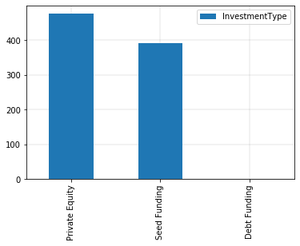

```python
fig,ax=plt.subplots()
New['InvestmentType'].value_counts().plot(kind='bar',legend=True)
ax.grid()
ax.set_axisbelow(True)
ax.grid(linestyle='-',linewidth='0.2',color='grey')
```

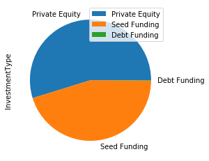

```python
New['InvestmentType'].value_counts().plot(kind='pie',legend=True)
```

```python
New['IndustryVertical'].value_counts()
```

```
Consumer Internet    459
Technology           189
eCommerce            112
ECommerce             32
Logistics             16
Education             15
Healthcare            14
Food & Beverage       12
Finance                7
Others                 4
FMCG                   2
Ecommerce              2
Reality                1
Real Estate            1
Food & Beverages       1
ecommerce              1
healthcare             1
Name: IndustryVertical, dtype: int64
```

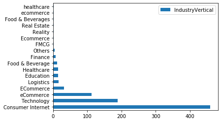

```python
New['IndustryVertical'].value_counts().plot(kind='barh',legend=True)
```

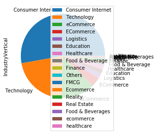

```python
New['IndustryVertical'].value_counts().plot(kind='pie',legend=True)
```

From above info we can say that consumer internet type of companies got more easily funding with some other like Technolgy and eCommerce.

```python
New['CityLocation'].value_counts()
```

```
Bangalore             267
Mumbai                181
New Delhi             130
Gurgaon                97
Pune                   37
Hyderabad              35
Noida                  33
Chennai                32
Ahmedabad              17
Kolkata                 5
Jaipur                  5
Vadodara                3
Indore                  3
Singapore               2
Chandigarh              2
Kanpur                  1
Pune/Seattle            1
Bangalore / SFO         1
Pune / Dubai            1
Trivandrum              1
Lucknow                 1
New Delhi / US          1
Varanasi                1
Coimbatore              1
Mumbai / UK             1
Goa                     1
Bangalore/ Bangkok      1
Missourie               1
Gwalior                 1
Bhopal                  1
Kerala                  1
SFO / Bangalore         1
Panaji                  1
Jodhpur                 1
Delhi                   1
Name: CityLocation, dtype: int64
```

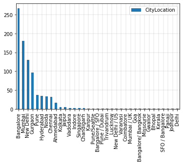

```python
fig,ax=plt.subplots()
New['CityLocation'].value_counts().plot(kind='bar',legend=True)
ax.grid()
ax.set_axisbelow(True)
ax.grid(linestyle='-',linewidth='0.2',color='grey')
```

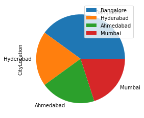

```python
a=New['CityLocation'].head()
a.value_counts().plot(kind='pie',legend=True)
```

Bangalore has the highest number of startups.

# Conclusion